# R语言编程补充

KJY / 2023-02-07

# R编程补充

2023-02-07

```r
addn = function(y) {
    function(x){
        x + y
    }
}
```

addn不是一个加法器，而是一个生成加法器的工厂！

```r
add1 = addn(1)
add2 = addn(2)
```

```r
add1(10)
```

```
## [1] 11
```

```r
add2(10)
```

```
## [1] 12
```

```r
add1
```

```
## function(x){
##         x + y
##     }
## <environment: 0x564d7a739360>
```

```r
add2
```

```
## function(x){
##         x + y
##     }
## <bytecode: 0x564d79b83f80>
## <environment: 0x564d7a78d220>
```

一个函数不在当前环境（例子中为全局环境）下，那么输出该函数就会一并显示其所属的环境。在add1的环境中，y是在addn(1)确定的

```r
environment(add1)$y
```

```
## [1] 1
```

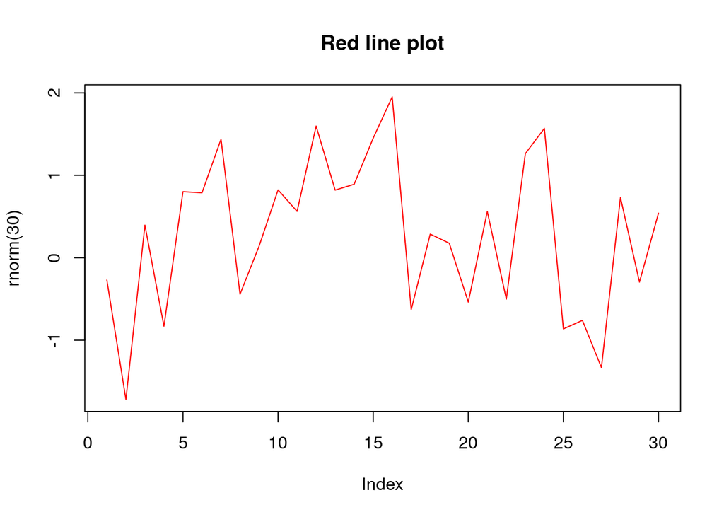

```r
color_line = function(col){
    function(...){
        plot(..., type = "l", lty = 1, col = col)
    }
}

red_line = color_line("red")
red_line(rnorm(30), main = "Red line plot")
```

```r
red_line
```

```
## function(...){
##         plot(..., type = "l", lty = 1, col = col)
##     }
## <environment: 0x564d79850718>
```

```r
environment(red_line)$col
```

```
## [1] "red"
```

```r
add = function(x, y, z ){
    x + y + z
}
product = function(x, y, z){
    x * y * z
}
combine = function(f, x, y, z){
    f(x, y, z)
}

combine(add, 3, 4, 5)
```

```
## [1] 12
```

```r
combine(product, 3, 4, 5)
```

```
## [1] 60
```

```r
iris[iris$Sepal.Length > quantile(iris$Sepal.Length, 0.8) &
         iris$Sepal.Width > quantile(iris$Sepal.Width, 0.8) &
         iris$Petal.Length > quantile(iris$Petal.Length, 0.8) &
         iris$Petal.Width > quantile(iris$Petal.Width, 0.8), ]
```

```
##     Sepal.Length Sepal.Width Petal.Length Petal.Width   Species
## 110          7.2         3.6          6.1         2.5 virginica
## 118          7.7         3.8          6.7         2.2 virginica
## 132          7.9         3.8          6.4         2.0 virginica
```

```r
subset(iris,
       Sepal.Length > quantile(Sepal.Length, 0.8) &
         Sepal.Width > quantile(Sepal.Width, 0.8) &
         Petal.Length > quantile(Petal.Length, 0.8) &
         Petal.Width > quantile(Petal.Width, 0.8))
```

```
##     Sepal.Length Sepal.Width Petal.Length Petal.Width   Species
## 110          7.2         3.6          6.1         2.5 virginica
## 118          7.7         3.8          6.7         2.2 virginica
## 132          7.9         3.8          6.4         2.0 virginica
```

subset()神奇之处在于它调整了参数被计算的环境，分两步完成，首先捕获表达式，然后调整表达式的计算。

捕获表达式意味着防止表达式被执行，而将表达式本身存储为变量的形式。具有这个功能的函数为quote()

```r
call1 = quote(rnorm(5))
call1
```

```
## rnorm(5)
```

```r
typeof(call1)
```

```
## [1] "language"
```

```r
class(call1)
```

```
## [1] "call"
```

call本质上是一个语言对象，并且是一个函数调用

```r
name1 = quote(rnorm)
typeof(name1)
```

```
## [1] "symbol"
```

```r
class(name1)
```

```
## [1] "name"
```

name是一个符号（或名称）而不是函数调用

事实上，quote()捕捉到函数调用时会返回调用，而捕获到变量名时则返回一个符号。

```r
as.list(call1)
```

```
## [[1]]
## rnorm
##
## [[2]]
## [1] 5
```

quote()捕获一个已知的表达式，而substitute()可以作用于任意的用户输入表达式。

```r
rnorm(5)
```

```
## [1]  1.3606034  0.1027449 -2.0280026 -0.3213873  1.2951472
```

```r
fun1 = function(x){
    quote(x)
}

fun1(rnorm(5))
```

```
## x
```

quote(x)捕获的是表达式x，而不是输入表达式rnorm(5)。下面使用substitute()：

```r
fun2 = function(x){
    substitute(x)
}
fun2(rnorm(5))
```

```
## rnorm(5)
```

```r
substitute(x + y + x ^2, list(x = 1))
```

```
## 1 + y + 1^2
```

```r
substitute(f(x + f(y)), list(f = quote(sin)))
```

```
## sin(x + sin(y))
```

```r
substitute(x, list(x = quote(rnorm(5))))
```

```
## rnorm(5)
```

表达式的捕获 和 执行表达式

最后一次修改于 2023-02-07